# Final Paper

Yohanes Woldeselassie

2023-10-15

## Factors Affecting Higher Education Dropout

### Introduction

Student dropout is a major problem in higher education. It is estimated that over 40% of students drop out of college before completing their degree program. This can have a significant impact on students’ future earnings and employment prospects. Because of this and personal interest as well to the subject matter i have chosen to work on a model that analyzes key factors (independent features) that affect student dropouts. I believe this is useful as it can help key stakeholders identify problems with students and provide the necessary support.

### Dataset

The createer of this data set is a student named Jeevabharathi S, who is a student from Tiruppur, Tamil Nadu, India. He also used the data set for a similar research owever his work was under python suing the Pandas library along with other libraries. Similar to both the Author (of the data set) as well as this research papers work readers can also attempt to create a model that can analyze key factors that affect the likelihood of students drop outs and even take the research further by attempting to create a model that can predict the likelihood of student dropouts before they happen.

#### Dataset Structure

```
## 'data.frame':    4424 obs. of  35 variables:
##  $ Marital.status                                : int  1 1 1 1 2 2 1 1 1 1 ...
##  $ Application.mode                              : int  8 6 1 8 12 12 1 9 1 1 ...
##  $ Application.order                             : int  5 1 5 2 1 1 1 4 3 1 ...
##  $ Course                                        : int  2 11 5 15 3 17 12 11 10 10 ...
##  $ Daytime.evening.attendance                    : int  1 1 1 1 0 0 1 1 1 1 ...
##  $ Previous.qualification                        : int  1 1 1 1 1 12 1 1 1 1 ...
##  $ Nacionality                                   : int  1 1 1 1 1 1 1 1 15 1 ...
##  $ Mother.s.qualification                        : int  13 1 22 23 22 22 13 22 1 1 ...
##  $ Father.s.qualification                        : int  10 3 27 27 28 27 28 27 1 14 ...
##  $ Mother.s.occupation                           : int  6 4 10 6 10 10 8 10 10 5 ...
##  $ Father.s.occupation                           : int  10 4 10 4 10 8 11 10 10 8 ...
##  $ Displaced                                     : int  1 1 1 1 0 0 1 1 0 1 ...
##  $ Educational.special.needs                     : int  0 0 0 0 0 0 0 0 0 0 ...
##  $ Debtor                                        : int  0 0 0 0 0 1 0 0 0 1 ...
```

[output cut: 21 more lines]

### Anticipated insights to be gained:

1. What are the key predictors of student dropouts?
2. Which students are most at risk of dropping out?
3. How can students’ ability to finish their coursework and graduate be improved?

### Plans of Analysis:

In terms of my plans for analysis, The project first intends to analyze and explore the data set along with performing data cleaning and pre processing (though in this case that is very minimal). Following that the next step will be to understand the data set further through the means of exploratory data analysis (EDA). After that step is complete the next step will be to explore different models and identify which model works best in explaining and highlighting which independent variables affects students drop outs most. Finally this project will attempt to create a predictive model that can predict the likelihood of students droping out. This will be done through the division of the model into a training and test case and after that through an iterative process this project will attempt to create the best model for prediction.

### Expected outcomes:

1. A predictive model that can identify students who are at risk of dropping out.
2. A better understanding of the key factors that affect dropouts.

### Conducted EDA

In the attempt to understand the data set further there have been several exploratory data analysis that have been performed. Including identifying the portion of students that have dropped out, are enrolled and graduated, The number of people in different genders, the portion of students that have a scholarship, the number of people that are daytime students and night time students and so on. Besides that there has also been more relational EDAs done between independent and dependent variables. for example analyzing the relationship between age and the students status (dropout, enrolled, and graduated) this was done through box plots. The results of all the EDA’s performed is as follows.

#### 1. Type of Student by Education Status

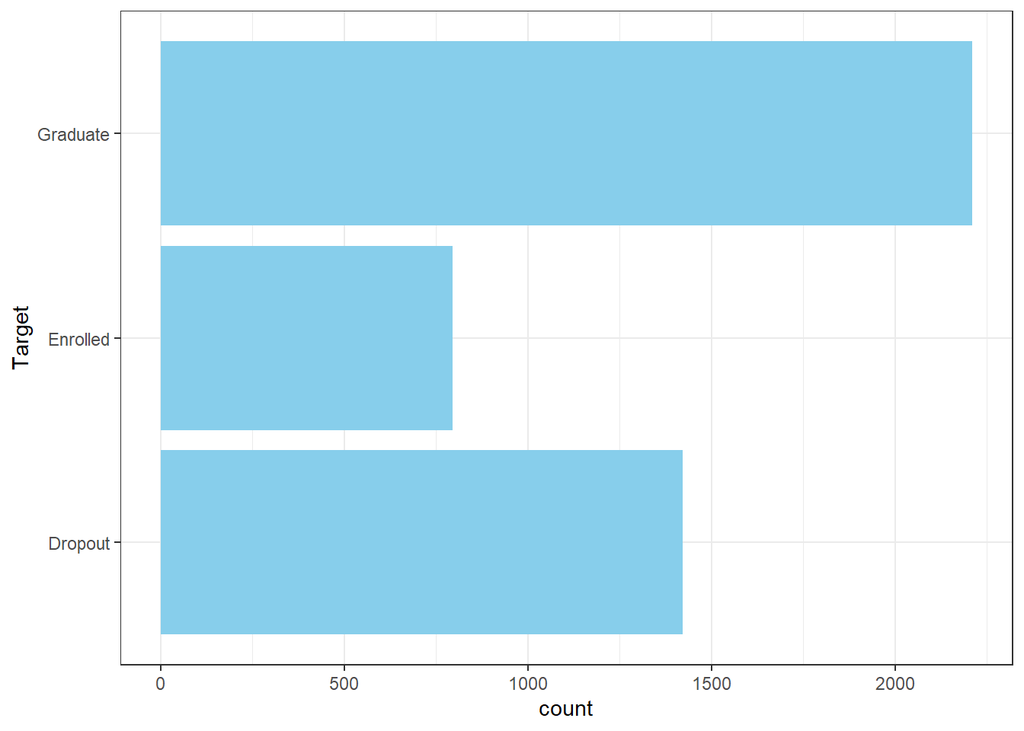

#### 2. Type of Studnt by Gender

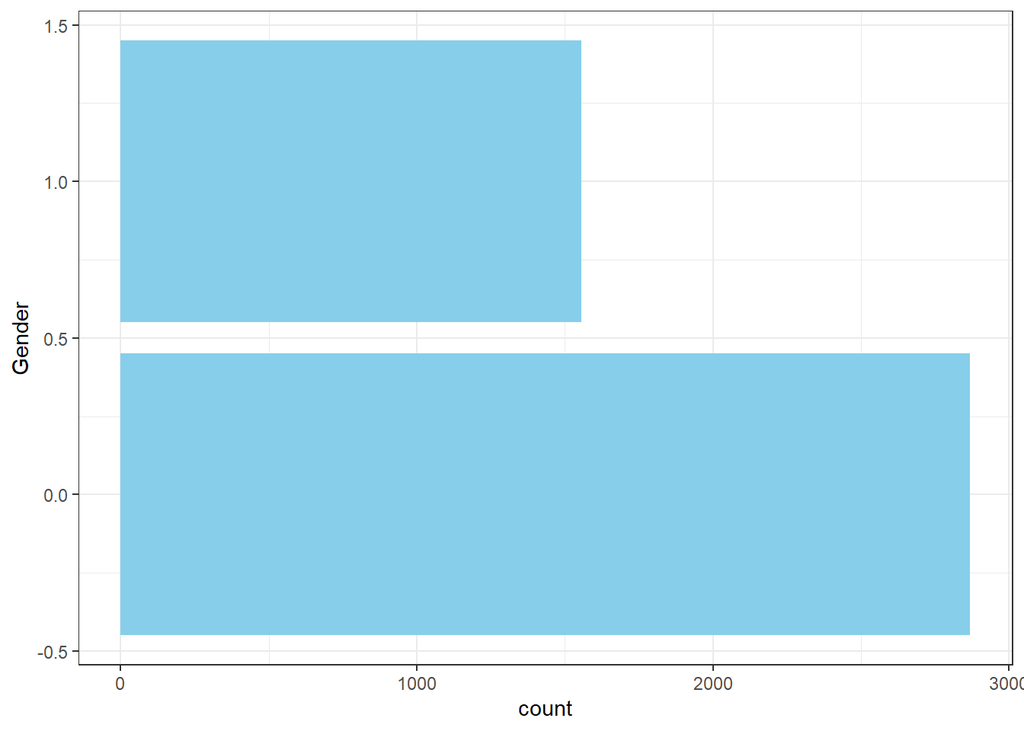

#### 3. Type of Student by Schoalrship Status

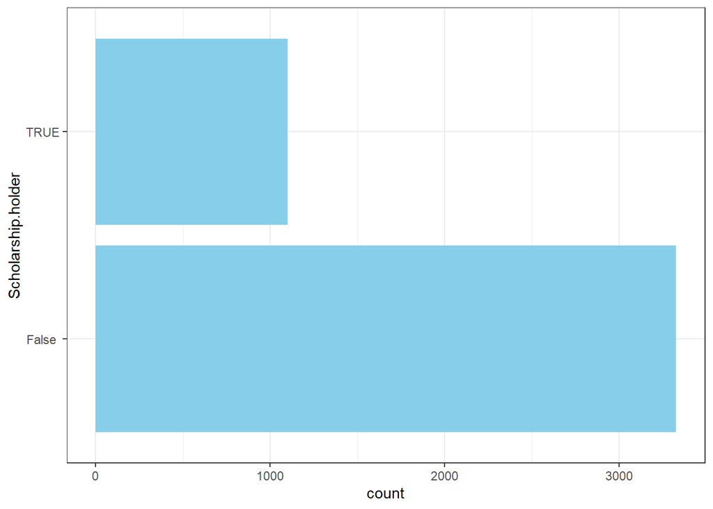

#### 4. Students program type

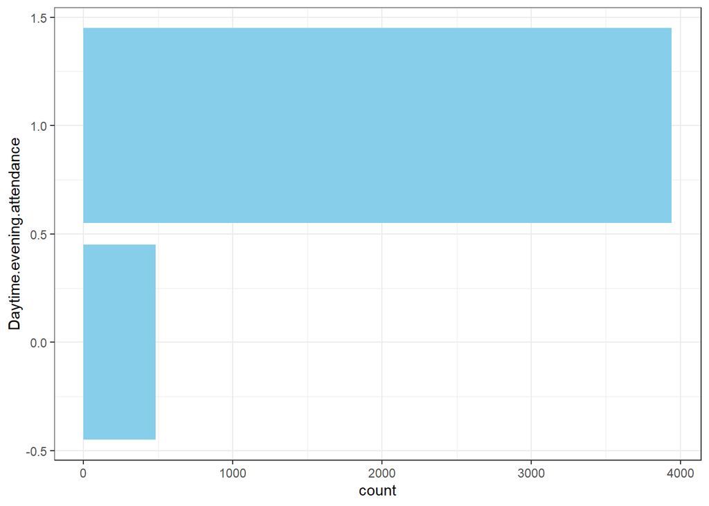

#### 5. Maritial Status of Students

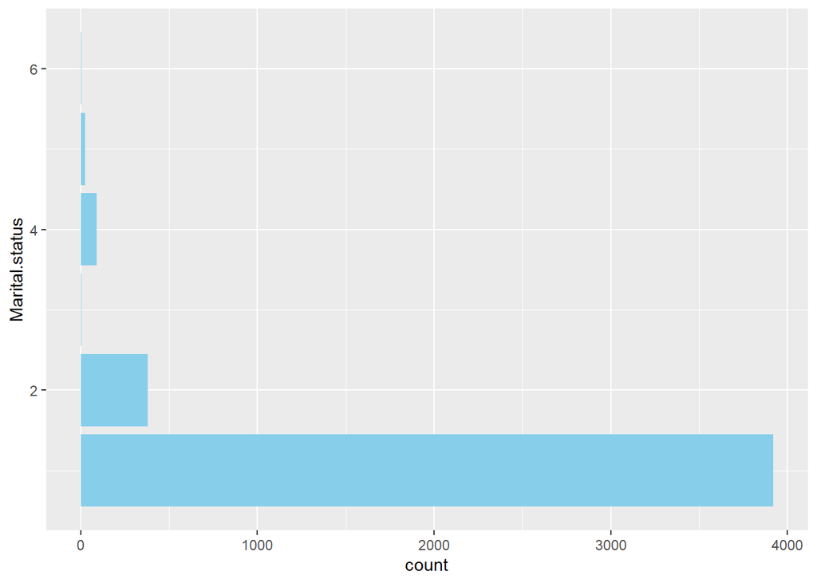

#### 6.Students age of Enrollment

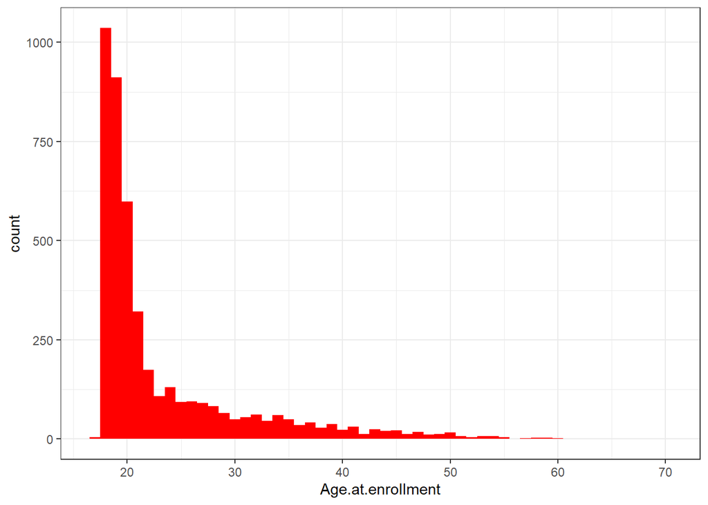

#### 7. Age of Enrollement vs Academic Status

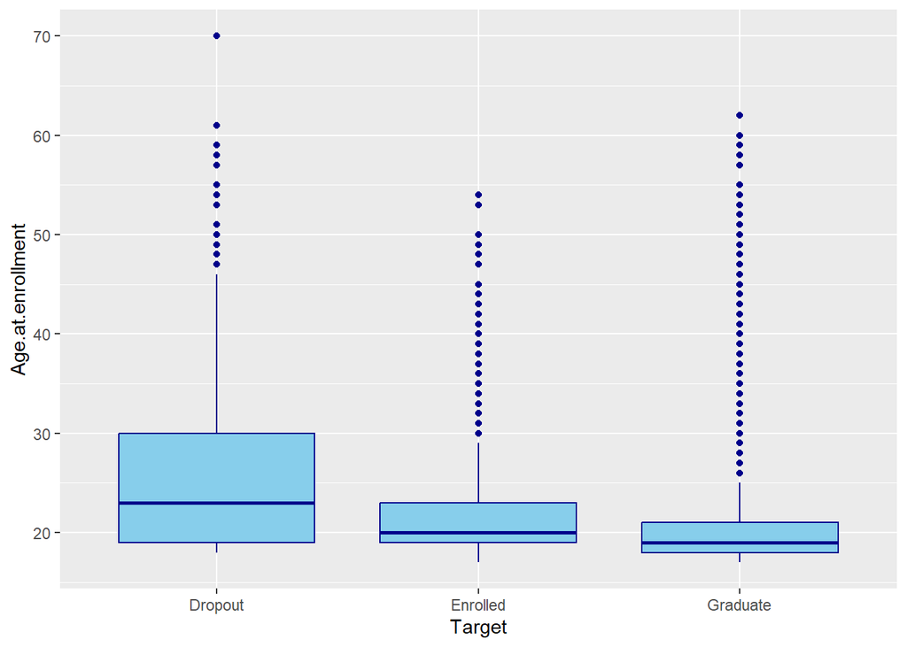

### Key Findings

Across all the models analyzed, two variables consistently emerged as highly significant drivers of student dropout behavior: “Tuition.fees.up.to.date” and “Curricular.units.2nd.sem..approved.” These variables exhibited significance in my analyses, reinforcing their importance in understanding the dynamics of student attrition. The results are as follows.

#### Results:

```
##
## Call:
## glm(formula = Target ~ Course + Previous.qualification + Father.s.qualification +
##     Tuition.fees.up.to.date + Age.at.enrollment + International +
##     Curricular.units.1st.sem..credited. + Curricular.units.1st.sem..approved. +
##     Curricular.units.2nd.sem..enrolled. + Curricular.units.2nd.sem..approved. +
##     Unemployment.rate + Inflation.rate, family = binomial(link = "probit"),
##     data = data2)
##
## Deviance Residuals:
##      Min        1Q    Median        3Q       Max
## -2.74543  -0.09315   0.20616   0.46360   2.76896
##
## Coefficients:
##                                     Estimate Std. Error z value Pr(>|z|)
## (Intercept)                          0.85431    0.70898   1.205 0.228212
## Course                              -0.08117    0.02852  -2.847 0.004418 **
## Previous.qualification               0.05029    0.02849   1.765 0.077577 .
## Father.s.qualification               0.02220    0.01047   2.119 0.034070 *
## Tuition.fees.up.to.date              1.37827    0.37754   3.651 0.000262 ***
## Age.at.enrollment                   -0.04563    0.01618  -2.821 0.004791 **
## International                        1.21531    0.73697   1.649 0.099137 .
## Curricular.units.1st.sem..credited. -0.24384    0.07653  -3.186 0.001441 **
## Curricular.units.1st.sem..approved.  0.25683    0.10617   2.419 0.015561 *
## Curricular.units.2nd.sem..enrolled. -0.27621    0.08453  -3.268 0.001085 **
## Curricular.units.2nd.sem..approved.  0.35484    0.09510   3.731 0.000191 ***
## Unemployment.rate                   -0.06616    0.04044  -1.636 0.101853
## Inflation.rate                      -0.19514    0.08008  -2.437 0.014820 *
## ---
## Signif. codes:  0 '***' 0.001 '**' 0.01 '*' 0.05 '.' 0.1 ' ' 1
##
## (Dispersion parameter for binomial family taken to be 1)
##
##     Null deviance: 361.29  on 299  degrees of freedom
## Residual deviance: 169.80  on 287  degrees of freedom
## AIC: 195.8
##
## Number of Fisher Scoring iterations: 7
```

```
##
## Call:
## glm(formula = Target ~ Course + Father.s.qualification + Tuition.fees.up.to.date +
##     Age.at.enrollment + International + Curricular.units.1st.sem..credited. +
##     Curricular.units.1st.sem..approved. + Curricular.units.2nd.sem..enrolled. +
##     Curricular.units.2nd.sem..approved. + Unemployment.rate +
##     Inflation.rate, family = binomial(link = "logit"), data = data2)
##
## Deviance Residuals:
##     Min       1Q   Median       3Q      Max
## -2.6880  -0.1470   0.2337   0.4669   2.5869
##
## Coefficients:
##                                     Estimate Std. Error z value Pr(>|z|)
## (Intercept)                          1.26591    1.24954   1.013 0.311011
## Course                              -0.14397    0.05163  -2.788 0.005299 **
## Father.s.qualification               0.04037    0.01931   2.091 0.036526 *
## Tuition.fees.up.to.date              2.35811    0.66596   3.541 0.000399 ***
## Age.at.enrollment                   -0.06151    0.02802  -2.195 0.028136 *
## International                        1.98819    1.29543   1.535 0.124839
## Curricular.units.1st.sem..credited. -0.42749    0.13922  -3.071 0.002136 **
## Curricular.units.1st.sem..approved.  0.42199    0.18956   2.226 0.026003 *
## Curricular.units.2nd.sem..enrolled. -0.44268    0.14630  -3.026 0.002479 **
## Curricular.units.2nd.sem..approved.  0.63686    0.17239   3.694 0.000221 ***
## Unemployment.rate                   -0.11761    0.07444  -1.580 0.114117
## Inflation.rate                      -0.36591    0.14669  -2.494 0.012617 *
## ---
## Signif. codes:  0 '***' 0.001 '**' 0.01 '*' 0.05 '.' 0.1 ' ' 1
##
## (Dispersion parameter for binomial family taken to be 1)
##
##     Null deviance: 361.29  on 299  degrees of freedom
## Residual deviance: 172.71  on 288  degrees of freedom
## AIC: 196.71
##
## Number of Fisher Scoring iterations: 6
```

#### Refrences:

Data source: https://www.kaggle.com/code/jeevabharathis/student-dropout-analysis-for-school-education

Data Author: Jeevabharathi S

Linkedin Profile: https://www.linkedin.com/in/jeevabharathi-s-aa2062248/